# Predict Bike Sharing Demand with AutoGluon Template

## Project: Predict Bike Sharing Demand with AutoGluon

This notebook is a template with each step that you need to complete for the project.

Please fill in your code where there are explicit `?` markers in the notebook. You are welcome to add more cells and code as you see fit.

Once you have completed all the code implementations, please export your notebook as a HTML file so the reviews can view your code. Make sure you have all outputs correctly outputted.

`File-> Export Notebook As... -> Export Notebook as HTML`

There is a writeup to complete as well after all code implememtation is done. Please answer all questions and attach the necessary tables and charts. You can complete the writeup in either markdown or PDF.

Completing the code template and writeup template will cover all of the rubric points for this project.

The rubric contains "Stand Out Suggestions" for enhancing the project beyond the minimum requirements. The stand out suggestions are optional. If you decide to pursue the "stand out suggestions", you can include the code in this notebook and also discuss the results in the writeup file.

## Step 1: Create an account with Kaggle

### Create Kaggle Account and download API key

Below is example of steps to get the API username and key. Each student will have their own username and key.

1. Open account settings.

2. Scroll down to API and click Create New API Token.

3. Open up `kaggle.json` and use the username and key.


## Step 2: Download the Kaggle dataset using the kaggle python library

### Open up Sagemaker Studio and use starter template

1. Notebook should be using a `ml.t3.medium` instance (2 vCPU + 4 GiB)
2. Notebook should be using kernal: `Python 3 (MXNet 1.8 Python 3.7 CPU Optimized)`

### Install packages

```python
!pip install -U pip
!pip install -U setuptools wheel
!pip install -U "mxnet<2.0.0" bokeh==2.0.1
!pip install autogluon --no-cache-dir
# Without --no-cache-dir, smaller aws instances may have trouble installing
# added this line, then commented out the "setup Kaggle API Key section
# this was advised by my Udacity instructor
!pip install -U kaggle
```

[output not shown]

### Setup Kaggle API Key

```python
# create the .kaggle directory and an empty kaggle.json file
#!mkdir -p /root/.kaggle
#!touch /root/.kaggle/kaggle.json
#!chmod 600 /root/.kaggle/kaggle.json
```

```python
# Fill in your user name and key from creating the kaggle account and API token file
import json
#kaggle_username = "FILL_IN_USERNAME"
#kaggle_key = "FILL_IN_KEY"

# Save API token the kaggle.json file
#with open("/root/.kaggle/kaggle.json", "w") as f:
    #f.write(json.dumps({"username": kaggle_username, "key": kaggle_key}))
```

### Download and explore dataset

### Go to the bike sharing demand competition and agree to the terms

```python
# Download the dataset, it will be in a .zip file so you'll need to unzip it as well.
!kaggle competitions download -c bike-sharing-demand
# If you already downloaded it you can use the -o command to overwrite the file
!unzip -o bike-sharing-demand.zip
```

```
Downloading bike-sharing-demand.zip to /root/project1/cd0385-project-starter/project
Archive:  bike-sharing-demand.zip
  inflating: sampleSubmission.csv
  inflating: test.csv
  inflating: train.csv
```

```python
import pandas as pd
from autogluon.tabular import TabularPredictor
```

[figure not shown]

```python
# Run this cell to import or install the Data Wrangler widget to show automatic visualization and generate code to fix data quality issues

try:
    import sagemaker_datawrangler
except ImportError:
    !pip install --upgrade sagemaker-datawrangler
    import sagemaker_datawrangler

# Display Pandas DataFrame to view the widget: df, display(df), df.sample()...
```

```python
# Run this cell to import or install the Data Wrangler widget to show automatic visualization and generate code to fix data quality issues

try:
    import sagemaker_datawrangler
except ImportError:
    !pip install --upgrade sagemaker-datawrangler
    import sagemaker_datawrangler

# Display Pandas DataFrame to view the widget: df, display(df), df.sample()...
```

```python
# Create the train dataset in pandas by reading the csv
train = pd.read_csv("./train.csv")
# Set the parsing of the datetime column so you can use some of the `dt` features in pandas later
train.loc[:, 'datetime'] = pd.to_datetime(train.datetime)
train.head()
```

```
             datetime  season  holiday  workingday  weather  temp   atemp  \
0 2011-01-01 00:00:00       1        0           0        1  9.84  14.395
1 2011-01-01 01:00:00       1        0           0        1  9.02  13.635
2 2011-01-01 02:00:00       1        0           0        1  9.02  13.635
3 2011-01-01 03:00:00       1        0           0        1  9.84  14.395
4 2011-01-01 04:00:00       1        0           0        1  9.84  14.395

   humidity  windspeed  casual  registered  count
0        81        0.0       3          13     16
1        80        0.0       8          32     40
2        80        0.0       5          27     32
3        75        0.0       3          10     13
4        75        0.0       0           1      1
```

```python
# Simple output of the train dataset to view some of the min/max/varition of the dataset features.
train.describe()
```

```
             season       holiday    workingday       weather         temp  \
count  10886.000000  10886.000000  10886.000000  10886.000000  10886.00000
mean       2.506614      0.028569      0.680875      1.418427     20.23086
std        1.116174      0.166599      0.466159      0.633839      7.79159
min        1.000000      0.000000      0.000000      1.000000      0.82000
25%        2.000000      0.000000      0.000000      1.000000     13.94000
50%        3.000000      0.000000      1.000000      1.000000     20.50000
75%        4.000000      0.000000      1.000000      2.000000     26.24000
max        4.000000      1.000000      1.000000      4.000000     41.00000

              atemp      humidity     windspeed        casual    registered  \
count  10886.000000  10886.000000  10886.000000  10886.000000  10886.000000
mean      23.655084     61.886460     12.799395     36.021955    155.552177
std        8.474601     19.245033      8.164537     49.960477    151.039033
min        0.760000      0.000000      0.000000      0.000000      0.000000
25%       16.665000     47.000000      7.001500      4.000000     36.000000
50%       24.240000     62.000000     12.998000     17.000000    118.000000
75%       31.060000     77.000000     16.997900     49.000000    222.000000
max       45.455000    100.000000     56.996900    367.000000    886.000000

              count
count  10886.000000
mean     191.574132
std      181.144454
min        1.000000
25%       42.000000
50%      145.000000
75%      284.000000
max      977.000000
```

```python
# Create the test pandas dataframe in pandas by reading the csv, remember to parse the datetime!
test = pd.read_csv("./test.csv", parse_dates=["datetime"])
test.head()
```

```
             datetime  season  holiday  workingday  weather   temp   atemp  \
0 2011-01-20 00:00:00       1        0           1        1  10.66  11.365
1 2011-01-20 01:00:00       1        0           1        1  10.66  13.635
2 2011-01-20 02:00:00       1        0           1        1  10.66  13.635
3 2011-01-20 03:00:00       1        0           1        1  10.66  12.880
4 2011-01-20 04:00:00       1        0           1        1  10.66  12.880

   humidity  windspeed
0        56    26.0027
1        56     0.0000
2        56     0.0000
3        56    11.0014
4        56    11.0014
```

```python
# Same thing as train and test dataset
submission = pd.read_csv("./sampleSubmission.csv", parse_dates=["datetime"])
submission.head()
```

```
             datetime  count
0 2011-01-20 00:00:00      0
1 2011-01-20 01:00:00      0
2 2011-01-20 02:00:00      0
3 2011-01-20 03:00:00      0
4 2011-01-20 04:00:00      0
```

## Step 3: Train a model using AutoGluon’s Tabular Prediction

Requirements:

- We are prediting `count`, so it is the label we are setting.
- Ignore `casual` and `registered` columns as they are also not present in the test dataset.
- Use the `root_mean_squared_error` as the metric to use for evaluation.
- Set a time limit of 10 minutes (600 seconds).
- Use the preset `best_quality` to focus on creating the best model.

```python
predictor = TabularPredictor(label="count",eval_metric="root_mean_squared_error",learner_kwargs={"ignored_columns": ["casual", "registered"]}).fit(train_data=train, time_limit=600, presets="best_quality")
```

```
No path specified. Models will be saved in: "AutogluonModels/ag-20230531_045004/"
Presets specified: ['best_quality']
Stack configuration (auto_stack=True): num_stack_levels=1, num_bag_folds=8, num_bag_sets=20
Beginning AutoGluon training ... Time limit = 600s
AutoGluon will save models to "AutogluonModels/ag-20230531_045004/"
AutoGluon Version:  0.6.2
Python Version:     3.7.10
Operating System:   Linux
Platform Machine:   x86_64
Platform Version:   #1 SMP Tue Apr 25 15:24:19 UTC 2023
Train Data Rows:    10886
Train Data Columns: 11
Label Column: count
Preprocessing data ...
AutoGluon infers your prediction problem is: 'regression' (because dtype of label-column == int and many unique label-values observed).
	Label info (max, min, mean, stddev): (977, 1, 191.57413, 181.14445)
	If 'regression' is not the correct problem_type, please manually specify the problem_type parameter during predictor init (You may specify problem_type as one of: ['binary', 'multiclass', 'regression'])
Using Feature Generators to preprocess the data ...
Dropping user-specified ignored columns: ['casual', 'registered']
Fitting AutoMLPipelineFeatureGenerator...
	Available Memory:                    1686.92 MB
	Train Data (Original)  Memory Usage: 0.78 MB (0.0% of available memory)
	Inferring data type of each feature based on column values. Set feature_metadata_in to manually specify special dtypes of the features.
	Stage 1 Generators:
		Fitting AsTypeFeatureGenerator...
			Note: Converting 2 features to boolean dtype as they only contain 2 unique values.
	Stage 2 Generators:
		Fitting FillNaFeatureGenerator...
	Stage 3 Generators:
		Fitting IdentityFeatureGenerator...
		Fitting DatetimeFeatureGenerator...
	Stage 4 Generators:
		Fitting DropUniqueFeatureGenerator...
	Types of features in original data (raw dtype, special dtypes):
		('datetime', []) : 1 | ['datetime']
		('float', [])    : 3 | ['temp', 'atemp', 'windspeed']
		('int', [])      : 5 | ['season', 'holiday', 'workingday', 'weather', 'humidity']
	Types of features in processed data (raw dtype, special dtypes):
		('float', [])                : 3 | ['temp', 'atemp', 'windspeed']
		('int', [])                  : 3 | ['season', 'weather', 'humidity']
```

[output cut: 64 more lines]

```
	-53.4233	 = Validation score   (-root_mean_squared_error)
	26.8s	 = Training   runtime
	0.6s	 = Validation runtime
Fitting model: CatBoost_BAG_L2 ... Training model for up to 58.62s of the 58.6s of remaining time.
	Fitting 8 child models (S1F1 - S1F8) | Fitting with ParallelLocalFoldFittingStrategy
	-55.8282	 = Validation score   (-root_mean_squared_error)
	59.11s	 = Training   runtime
	0.06s	 = Validation runtime
Completed 1/20 k-fold bagging repeats ...
Fitting model: WeightedEnsemble_L3 ... Training model for up to 360.0s of the -4.7s of remaining time.
	-53.137	 = Validation score   (-root_mean_squared_error)
	1.2s	 = Training   runtime
	0.0s	 = Validation runtime
AutoGluon training complete, total runtime = 606.19s ... Best model: "WeightedEnsemble_L3"
TabularPredictor saved. To load, use: predictor = TabularPredictor.load("AutogluonModels/ag-20230531_045004/")
```

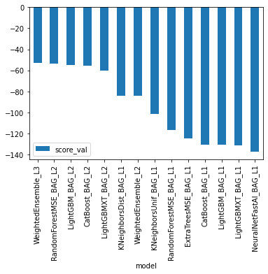

```python
# look at the model's score_val in a bar chart to analyze performance
predictor.leaderboard(silent=True).plot(kind="bar", x="model", y="score_val")
```

### Review AutoGluon's training run with ranking of models that did the best.

```python
predictor.fit_summary()
```

```
*** Summary of fit() ***
Estimated performance of each model:
                     model   score_val  pred_time_val    fit_time  pred_time_val_marginal  fit_time_marginal  stack_level  can_infer  fit_order
0      WeightedEnsemble_L3  -53.137000      14.312073  562.985014                0.001420           1.201369            3       True         14
1   RandomForestMSE_BAG_L2  -53.423261      10.363982  420.360158                0.602145          26.803882            2       True         12
2          LightGBM_BAG_L2  -55.228201      10.000289  418.009933                0.238452          24.453657            2       True         11
3          CatBoost_BAG_L2  -55.828232       9.825272  452.664367                0.063435          59.108091            2       True         13
4        LightGBMXT_BAG_L2  -60.234547      13.406622  451.418015                3.644785          57.861739            2       True         10
5    KNeighborsDist_BAG_L1  -84.125061       0.103742    0.029773                0.103742           0.029773            1       True          2
6      WeightedEnsemble_L2  -84.125061       0.104554    0.545621                0.000812           0.515848            2       True          9
7    KNeighborsUnif_BAG_L1 -101.546199       0.103887    0.032737                0.103887           0.032737            1       True          1
8   RandomForestMSE_BAG_L1 -116.544294       0.699667   11.189819                0.699667          11.189819            1       True          5
9     ExtraTreesMSE_BAG_L1 -124.588053       0.525070    4.947886                0.525070           4.947886            1       True          7
10         CatBoost_BAG_L1 -130.516597       0.134355  205.148135                0.134355         205.148135            1       True          6
11         LightGBM_BAG_L1 -131.054162       1.373583   29.425077                1.373583          29.425077            1       True          4
12       LightGBMXT_BAG_L1 -131.460909       6.251276   65.466869                6.251276          65.466869            1       True          3
13  NeuralNetFastAI_BAG_L1 -137.698718       0.570259   77.315981                0.570259          77.315981            1       True          8
Number of models trained: 14
Types of models trained:
{'StackerEnsembleModel_KNN', 'StackerEnsembleModel_LGB', 'WeightedEnsembleModel', 'StackerEnsembleModel_NNFastAiTabular', 'StackerEnsembleModel_CatBoost', 'StackerEnsembleModel_XT', 'StackerEnsembleModel_RF'}
Bagging used: True  (with 8 folds)
Multi-layer stack-ensembling used: True  (with 3 levels)
Feature Metadata (Processed):
(raw dtype, special dtypes):
('float', [])                : 3 | ['temp', 'atemp', 'windspeed']
('int', [])                  : 3 | ['season', 'weather', 'humidity']
('int', ['bool'])            : 2 | ['holiday', 'workingday']
('int', ['datetime_as_int']) : 5 | ['datetime', 'datetime.year', 'datetime.month', 'datetime.day', 'datetime.dayofweek']
Plot summary of models saved to file: AutogluonModels/ag-20230531_045004/SummaryOfModels.html
*** End of fit() summary ***
```

[output not shown]

[output cut: 126 more lines]

```
     fit_order
 0          14
 1          12
 2          11
 3          13
 4          10
 5           2
 6           9
 7           1
 8           5
 9           7
 10          6
 11          4
 12          3
 13          8  }
```

### Create predictions from test dataset

```python
predictions = predictor.predict(test)
predictions.head()
```

```
0    23.355520
1    41.657818
2    45.003624
3    48.290298
4    51.302368
Name: count, dtype: float32
```

#### NOTE: Kaggle will reject the submission if we don't set everything to be > 0.

```python
# Describe the `predictions` series to see if there are any negative values
predictions.describe()
```

```
count    6493.000000
mean      100.931526
std        90.225006
min         3.074520
25%        20.409826
50%        64.194710
75%       167.690430
max       365.805023
Name: count, dtype: float64
```

```python
# How many negative values do we have?
predictions.lt(0).value_counts()
```

```
False    6493
Name: count, dtype: int64
```

```python
# Set them to zero
predictions.iloc[predictions<0] = 0
```

### Set predictions to submission dataframe, save, and submit

```python
submission["count"] = predictions
submission.to_csv("final_first_raw_submission.csv", index=False)
```

```python
!kaggle competitions submit -c bike-sharing-demand -f final_first_raw_submission.csv -m "FINAL first raw submission"
```

```
Successfully submitted to Bike Sharing Demand
```

#### View submission via the command line or in the web browser under the competition's page - `My Submissions`

```python
!kaggle competitions submissions -c bike-sharing-demand | tail -n +1 | head -n 6
```

```
fileName                           date                 description                             status    publicScore  privateScore
---------------------------------  -------------------  --------------------------------------  --------  -----------  ------------
final_first_raw_submission.csv     2023-05-31 05:02:25  FINAL first raw submission              complete  1.79675      1.79675
submission_new_features.csv        2023-05-30 23:33:23  1 new features                          complete  1.34071      1.34071
submission.csv                     2023-05-30 23:19:01  1 first raw submission                  complete  1.34056      1.34056
new_submission_hpo_best.csv        2023-05-30 22:56:40  best new features with hyperparameters  complete  1.19182      1.19182
```

#### Initial score of 1.7967

## Step 4: Exploratory Data Analysis and Creating an additional feature

- Any additional feature will do, but a great suggestion would be to separate out the datetime into hour, day, or month parts.

```
array([[<AxesSubplot:title={'center':'datetime'}>,
        <AxesSubplot:title={'center':'season'}>,
        <AxesSubplot:title={'center':'holiday'}>],
       [<AxesSubplot:title={'center':'workingday'}>,
        <AxesSubplot:title={'center':'weather'}>,
        <AxesSubplot:title={'center':'temp'}>],
       [<AxesSubplot:title={'center':'atemp'}>,
        <AxesSubplot:title={'center':'humidity'}>,
        <AxesSubplot:title={'center':'windspeed'}>],
       [<AxesSubplot:title={'center':'casual'}>,
        <AxesSubplot:title={'center':'registered'}>,
        <AxesSubplot:title={'center':'count'}>]], dtype=object)
```

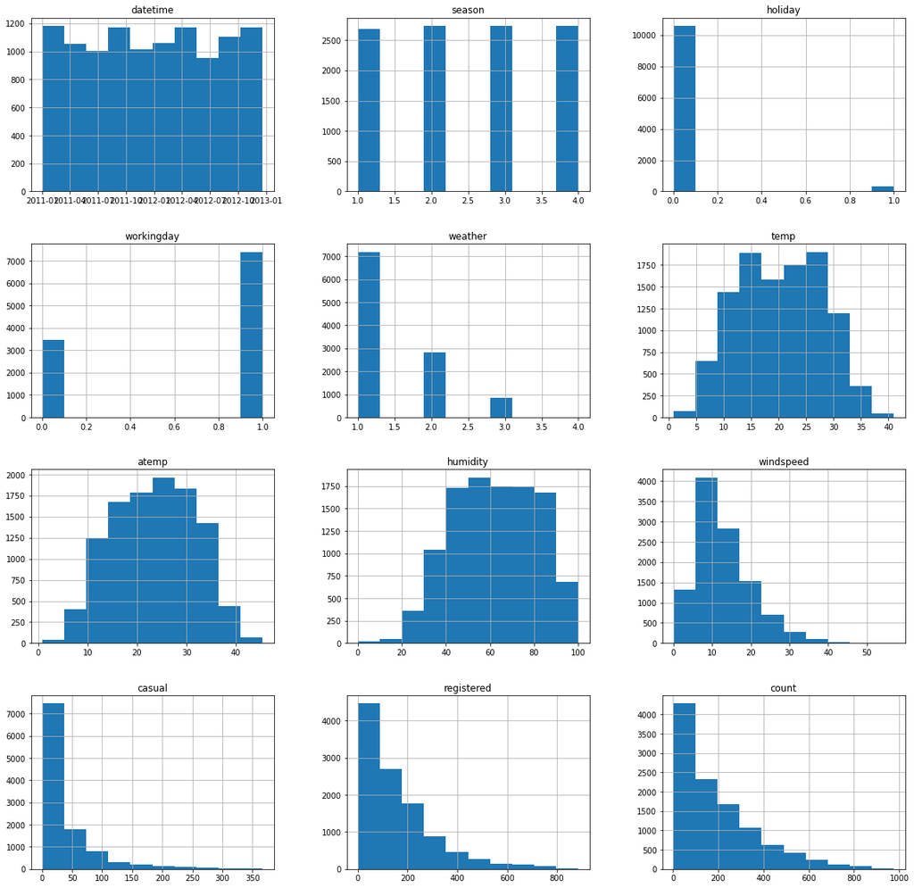

```python
# Create a histogram of all features to show the distribution of each one relative to the data. This is part of the exploritory data analysis
train.hist(figsize=(20,20))
```

```python
# create a new feature
train["year"] = train.datetime.dt.year
train["month"] = train.datetime.dt.month
train["day"] = train.datetime.dt.day
train["hour"] = train.datetime.dt.hour

test["year"] = test.datetime.dt.year
test["month"] = test.datetime.dt.month
test["day"] = test.datetime.dt.day
test["hour"] = test.datetime.dt.hour
```

```python
train.head()
```

```
             datetime  season  holiday  workingday  weather  temp   atemp  \
0 2011-01-01 00:00:00       1        0           0        1  9.84  14.395
1 2011-01-01 01:00:00       1        0           0        1  9.02  13.635
2 2011-01-01 02:00:00       1        0           0        1  9.02  13.635
3 2011-01-01 03:00:00       1        0           0        1  9.84  14.395
4 2011-01-01 04:00:00       1        0           0        1  9.84  14.395

   humidity  windspeed  casual  registered  count  year  month  day  hour
0        81        0.0       3          13     16  2011      1    1     0
1        80        0.0       8          32     40  2011      1    1     1
2        80        0.0       5          27     32  2011      1    1     2
3        75        0.0       3          10     13  2011      1    1     3
4        75        0.0       0           1      1  2011      1    1     4
```

```python
test.head()
```

```
             datetime  season  holiday  workingday  weather   temp   atemp  \
0 2011-01-20 00:00:00       1        0           1        1  10.66  11.365
1 2011-01-20 01:00:00       1        0           1        1  10.66  13.635
2 2011-01-20 02:00:00       1        0           1        1  10.66  13.635
3 2011-01-20 03:00:00       1        0           1        1  10.66  12.880
4 2011-01-20 04:00:00       1        0           1        1  10.66  12.880

   humidity  windspeed  year  month  day  hour
0        56    26.0027  2011      1   20     0
1        56     0.0000  2011      1   20     1
2        56     0.0000  2011      1   20     2
3        56    11.0014  2011      1   20     3
4        56    11.0014  2011      1   20     4
```

## Make category types for these so models know they are not just numbers

- AutoGluon originally sees these as ints, but in reality they are int representations of a category.
- Setting the dtype to category will classify these as categories in AutoGluon.

```python
train["season"] = train["season"].astype("category")
train["weather"] = train["weather"].astype("category")
test["season"] = test["season"].astype("category")
test["weather"] = test["weather"].astype("category")
```

```python
# View our new feature
train.head()
```

```
             datetime season  holiday  workingday weather  temp   atemp  \
0 2011-01-01 00:00:00      1        0           0       1  9.84  14.395
1 2011-01-01 01:00:00      1        0           0       1  9.02  13.635
2 2011-01-01 02:00:00      1        0           0       1  9.02  13.635
3 2011-01-01 03:00:00      1        0           0       1  9.84  14.395
4 2011-01-01 04:00:00      1        0           0       1  9.84  14.395

   humidity  windspeed  casual  registered  count  year  month  day  hour
0        81        0.0       3          13     16  2011      1    1     0
1        80        0.0       8          32     40  2011      1    1     1
2        80        0.0       5          27     32  2011      1    1     2
3        75        0.0       3          10     13  2011      1    1     3
4        75        0.0       0           1      1  2011      1    1     4
```

```
array([[<AxesSubplot:title={'center':'datetime'}>,
        <AxesSubplot:title={'center':'holiday'}>,
        <AxesSubplot:title={'center':'workingday'}>,
        <AxesSubplot:title={'center':'temp'}>],
       [<AxesSubplot:title={'center':'atemp'}>,
        <AxesSubplot:title={'center':'humidity'}>,
        <AxesSubplot:title={'center':'windspeed'}>,
        <AxesSubplot:title={'center':'casual'}>],
       [<AxesSubplot:title={'center':'registered'}>,
        <AxesSubplot:title={'center':'count'}>,
        <AxesSubplot:title={'center':'year'}>,
        <AxesSubplot:title={'center':'month'}>],
       [<AxesSubplot:title={'center':'day'}>,
        <AxesSubplot:title={'center':'hour'}>, <AxesSubplot:>,
        <AxesSubplot:>]], dtype=object)
```

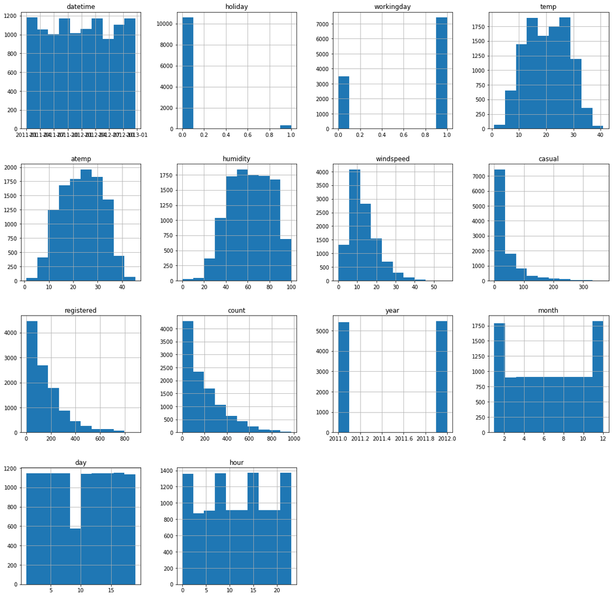

```python
# View histogram of all features again now with the hour feature
train.hist(figsize=(20,20))
```

## Step 5: Rerun the model with the same settings as before, just with more features

```python
predictor_new_features = TabularPredictor(label="count",eval_metric="root_mean_squared_error",learner_kwargs={"ignored_columns": ["casual", "registered"]}).fit(train_data=train, time_limit=600, presets="best_quality")
```

```
No path specified. Models will be saved in: "AutogluonModels/ag-20230531_050755/"
Presets specified: ['best_quality']
Stack configuration (auto_stack=True): num_stack_levels=1, num_bag_folds=8, num_bag_sets=20
Beginning AutoGluon training ... Time limit = 600s
AutoGluon will save models to "AutogluonModels/ag-20230531_050755/"
AutoGluon Version:  0.6.2
Python Version:     3.7.10
Operating System:   Linux
Platform Machine:   x86_64
Platform Version:   #1 SMP Tue Apr 25 15:24:19 UTC 2023
Train Data Rows:    10886
Train Data Columns: 15
Label Column: count
Preprocessing data ...
AutoGluon infers your prediction problem is: 'regression' (because dtype of label-column == int and many unique label-values observed).
	Label info (max, min, mean, stddev): (977, 1, 191.57413, 181.14445)
	If 'regression' is not the correct problem_type, please manually specify the problem_type parameter during predictor init (You may specify problem_type as one of: ['binary', 'multiclass', 'regression'])
Using Feature Generators to preprocess the data ...
Dropping user-specified ignored columns: ['casual', 'registered']
Fitting AutoMLPipelineFeatureGenerator...
	Available Memory:                    1532.2 MB
	Train Data (Original)  Memory Usage: 0.98 MB (0.1% of available memory)
	Inferring data type of each feature based on column values. Set feature_metadata_in to manually specify special dtypes of the features.
	Stage 1 Generators:
		Fitting AsTypeFeatureGenerator...
			Note: Converting 3 features to boolean dtype as they only contain 2 unique values.
	Stage 2 Generators:
		Fitting FillNaFeatureGenerator...
	Stage 3 Generators:
		Fitting IdentityFeatureGenerator...
		Fitting CategoryFeatureGenerator...
			Fitting CategoryMemoryMinimizeFeatureGenerator...
		Fitting DatetimeFeatureGenerator...
	Stage 4 Generators:
		Fitting DropUniqueFeatureGenerator...
	Types of features in original data (raw dtype, special dtypes):
		('category', []) : 2 | ['season', 'weather']
		('datetime', []) : 1 | ['datetime']
		('float', [])    : 3 | ['temp', 'atemp', 'windspeed']
		('int', [])      : 7 | ['holiday', 'workingday', 'humidity', 'year', 'month', ...]
```

[output cut: 68 more lines]

```
	-31.5019	 = Validation score   (-root_mean_squared_error)
	31.55s	 = Training   runtime
	0.63s	 = Validation runtime
Fitting model: CatBoost_BAG_L2 ... Training model for up to 72.67s of the 72.64s of remaining time.
	Fitting 8 child models (S1F1 - S1F8) | Fitting with ParallelLocalFoldFittingStrategy
	-30.3951	 = Validation score   (-root_mean_squared_error)
	71.31s	 = Training   runtime
	0.13s	 = Validation runtime
Completed 1/20 k-fold bagging repeats ...
Fitting model: WeightedEnsemble_L3 ... Training model for up to 360.0s of the -2.77s of remaining time.
	-30.096	 = Validation score   (-root_mean_squared_error)
	0.32s	 = Training   runtime
	0.0s	 = Validation runtime
AutoGluon training complete, total runtime = 603.29s ... Best model: "WeightedEnsemble_L3"
TabularPredictor saved. To load, use: predictor = TabularPredictor.load("AutogluonModels/ag-20230531_050755/")
```

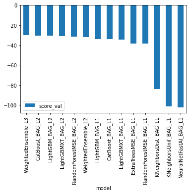

```python
# look at the model's score_val in a bar chart to analyze performance
predictor_new_features.leaderboard(silent=True).plot(kind="bar", x="model", y="score_val")
```

```python
predictor_new_features.fit_summary()
```

```
*** Summary of fit() ***
Estimated performance of each model:
                     model   score_val  pred_time_val    fit_time  pred_time_val_marginal  fit_time_marginal  stack_level  can_infer  fit_order
0      WeightedEnsemble_L3  -30.096013      16.271074  528.584767                0.001225           0.319210            3       True         14
1          CatBoost_BAG_L2  -30.395083      14.883971  471.289175                0.125715          71.308873            2       True         13
2          LightGBM_BAG_L2  -30.450843      15.009554  425.770478                0.251298          25.790176            2       True         11
3        LightGBMXT_BAG_L2  -31.113839      15.892835  431.166508                1.134579          31.186206            2       True         10
4   RandomForestMSE_BAG_L2  -31.501852      15.384024  431.528590                0.625768          31.548288            2       True         12
5      WeightedEnsemble_L2  -32.132427      13.585812  353.054361                0.005271           1.971124            2       True          9
6          LightGBM_BAG_L1  -33.917339       3.379249   45.029974                3.379249          45.029974            1       True          4
7          CatBoost_BAG_L1  -33.970390       0.184966  205.452296                0.184966         205.452296            1       True          6
8        LightGBMXT_BAG_L1  -34.345997       9.339568   86.595849                9.339568          86.595849            1       True          3
9     ExtraTreesMSE_BAG_L1  -38.295243       0.566628    6.365705                0.566628           6.365705            1       True          7
10  RandomForestMSE_BAG_L1  -38.314947       0.572726   13.969615                0.572726          13.969615            1       True          5
11   KNeighborsDist_BAG_L1  -84.125061       0.104032    0.035503                0.104032           0.035503            1       True          2
12   KNeighborsUnif_BAG_L1 -101.546199       0.107449    0.036595                0.107449           0.036595            1       True          1
13  NeuralNetFastAI_BAG_L1 -102.591981       0.503638   42.494765                0.503638          42.494765            1       True          8
Number of models trained: 14
Types of models trained:
{'StackerEnsembleModel_KNN', 'StackerEnsembleModel_LGB', 'WeightedEnsembleModel', 'StackerEnsembleModel_NNFastAiTabular', 'StackerEnsembleModel_CatBoost', 'StackerEnsembleModel_XT', 'StackerEnsembleModel_RF'}
Bagging used: True  (with 8 folds)
Multi-layer stack-ensembling used: True  (with 3 levels)
Feature Metadata (Processed):
(raw dtype, special dtypes):
('category', [])             : 2 | ['season', 'weather']
('float', [])                : 3 | ['temp', 'atemp', 'windspeed']
('int', [])                  : 4 | ['humidity', 'month', 'day', 'hour']
('int', ['bool'])            : 3 | ['holiday', 'workingday', 'year']
('int', ['datetime_as_int']) : 5 | ['datetime', 'datetime.year', 'datetime.month', 'datetime.day', 'datetime.dayofweek']
Plot summary of models saved to file: AutogluonModels/ag-20230531_050755/SummaryOfModels.html
*** End of fit() summary ***
```

[output not shown]

[output cut: 126 more lines]

```
     fit_order
 0          14
 1          13
 2          11
 3          10
 4          12
 5           9
 6           4
 7           6
 8           3
 9           7
 10          5
 11          2
 12          1
 13          8  }
```

```python
predictions_new_features = predictor_new_features.predict(test)
predictions_new_features.head()
```

```
0    15.709799
1    11.857940
2    10.737974
3     9.516422
4     8.352930
Name: count, dtype: float32
```

```python
# Describe the `predictions` series to see if there are any negative values
predictions_new_features.describe()
```

```
count    6493.000000
mean      153.113647
std       132.090515
min         2.270169
25%        53.625320
50%       119.725372
75%       215.949188
max       818.720764
Name: count, dtype: float64
```

```python
# count negatives
predictions_new_features.lt(0).value_counts()
# Remember to set all negative values to zero
predictions_new_features.iloc[predictions_new_features<0] = 0
```

```python
# Same submitting predictions
submission_new_features = pd.read_csv("./sampleSubmission.csv", parse_dates=["datetime"])
submission_new_features["count"] = predictions_new_features
submission_new_features.to_csv("final_submission_new_features.csv", index=False)
```

```python
!kaggle competitions submit -c bike-sharing-demand -f final_submission_new_features.csv -m "final new features"
```

```
Successfully submitted to Bike Sharing Demand
```

```python
!kaggle competitions submissions -c bike-sharing-demand | tail -n +1 | head -n 6
```

```
fileName                           date                 description                             status    publicScore  privateScore
---------------------------------  -------------------  --------------------------------------  --------  -----------  ------------
final_submission_new_features.csv  2023-05-31 05:34:02  final new features                      complete  0.67897      0.67897
final_submission_new_features.csv  2023-05-31 05:24:20  final new features                      complete  0.67897      0.67897
final_first_raw_submission.csv     2023-05-31 05:02:25  FINAL first raw submission              complete  1.79675      1.79675
submission_new_features.csv        2023-05-30 23:33:23  1 new features                          complete  1.34071      1.34071
```

#### New Score of 0.6789

## Step 6: Hyper parameter optimization

- There are many options for hyper parameter optimization.
- Options are to change the AutoGluon higher level parameters or the individual model hyperparameters.
- The hyperparameters of the models themselves that are in AutoGluon. Those need the `hyperparameter` and `hyperparameter_tune_kwargs` arguments.

```python
# Repeat step 5, but specify problem_type = "regression"
predictor_regression = TabularPredictor(label="count",problem_type = "regression",eval_metric="root_mean_squared_error",learner_kwargs={"ignored_columns": ["casual", "registered"]}).fit(train_data=train, time_limit=600, presets="best_quality")
```

```
No path specified. Models will be saved in: "AutogluonModels/ag-20230531_053606/"
Presets specified: ['best_quality']
Stack configuration (auto_stack=True): num_stack_levels=1, num_bag_folds=8, num_bag_sets=20
Beginning AutoGluon training ... Time limit = 600s
AutoGluon will save models to "AutogluonModels/ag-20230531_053606/"
AutoGluon Version:  0.6.2
Python Version:     3.7.10
Operating System:   Linux
Platform Machine:   x86_64
Platform Version:   #1 SMP Tue Apr 25 15:24:19 UTC 2023
Train Data Rows:    10886
Train Data Columns: 15
Label Column: count
Preprocessing data ...
Using Feature Generators to preprocess the data ...
Dropping user-specified ignored columns: ['casual', 'registered']
Fitting AutoMLPipelineFeatureGenerator...
	Available Memory:                    1729.64 MB
	Train Data (Original)  Memory Usage: 0.98 MB (0.1% of available memory)
	Inferring data type of each feature based on column values. Set feature_metadata_in to manually specify special dtypes of the features.
	Stage 1 Generators:
		Fitting AsTypeFeatureGenerator...
			Note: Converting 3 features to boolean dtype as they only contain 2 unique values.
	Stage 2 Generators:
		Fitting FillNaFeatureGenerator...
	Stage 3 Generators:
		Fitting IdentityFeatureGenerator...
		Fitting CategoryFeatureGenerator...
			Fitting CategoryMemoryMinimizeFeatureGenerator...
		Fitting DatetimeFeatureGenerator...
	Stage 4 Generators:
		Fitting DropUniqueFeatureGenerator...
	Types of features in original data (raw dtype, special dtypes):
		('category', []) : 2 | ['season', 'weather']
		('datetime', []) : 1 | ['datetime']
		('float', [])    : 3 | ['temp', 'atemp', 'windspeed']
		('int', [])      : 7 | ['holiday', 'workingday', 'humidity', 'year', 'month', ...]
	Types of features in processed data (raw dtype, special dtypes):
		('category', [])             : 2 | ['season', 'weather']
		('float', [])                : 3 | ['temp', 'atemp', 'windspeed']
```

[output cut: 65 more lines]

```
	-31.4745	 = Validation score   (-root_mean_squared_error)
	31.73s	 = Training   runtime
	0.62s	 = Validation runtime
Fitting model: CatBoost_BAG_L2 ... Training model for up to 71.31s of the 71.29s of remaining time.
	Fitting 8 child models (S1F1 - S1F8) | Fitting with ParallelLocalFoldFittingStrategy
	-30.4869	 = Validation score   (-root_mean_squared_error)
	69.56s	 = Training   runtime
	0.08s	 = Validation runtime
Completed 1/20 k-fold bagging repeats ...
Fitting model: WeightedEnsemble_L3 ... Training model for up to 360.0s of the -2.71s of remaining time.
	-30.1664	 = Validation score   (-root_mean_squared_error)
	0.29s	 = Training   runtime
	0.0s	 = Validation runtime
AutoGluon training complete, total runtime = 603.19s ... Best model: "WeightedEnsemble_L3"
TabularPredictor saved. To load, use: predictor = TabularPredictor.load("AutogluonModels/ag-20230531_053606/")
```

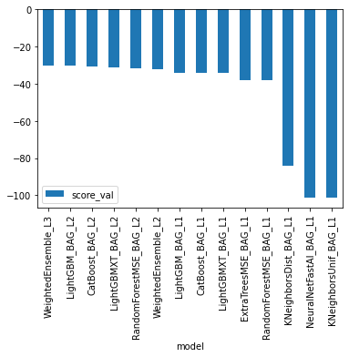

```python
# look at the model's score_val in a bar chart to analyze performance
predictor_regression.leaderboard(silent=True).plot(kind="bar", x="model", y="score_val")
```

```python
predictor_regression.fit_summary()
```

```
*** Summary of fit() ***
Estimated performance of each model:
                     model   score_val  pred_time_val    fit_time  pred_time_val_marginal  fit_time_marginal  stack_level  can_infer  fit_order
0      WeightedEnsemble_L3  -30.166420      16.478538  561.665266                0.000833           0.285446            3       True         14
1          LightGBM_BAG_L2  -30.460957      14.857432  428.948980                0.276948          26.141463            2       True         11
2          CatBoost_BAG_L2  -30.486866      14.664622  472.369085                0.084138          69.561568            2       True         13
3        LightGBMXT_BAG_L2  -31.262018      15.496362  433.949961                0.915878          31.142444            2       True         10
4   RandomForestMSE_BAG_L2  -31.474473      15.200739  434.534345                0.620256          31.726828            2       True         12
5      WeightedEnsemble_L2  -32.130091      13.461847  350.574051                0.000983           0.510247            2       True          9
6          LightGBM_BAG_L1  -33.917339       3.404582   43.883627                3.404582          43.883627            1       True          4
7          CatBoost_BAG_L1  -33.953258       0.181422  207.690615                0.181422         207.690615            1       True          6
8        LightGBMXT_BAG_L1  -34.345997       9.093173   84.578610                9.093173          84.578610            1       True          3
9     ExtraTreesMSE_BAG_L1  -38.295243       0.553182    6.405372                0.553182           6.405372            1       True          7
10  RandomForestMSE_BAG_L1  -38.314947       0.572001   13.873304                0.572001          13.873304            1       True          5
11   KNeighborsDist_BAG_L1  -84.125061       0.209686    0.037648                0.209686           0.037648            1       True          2
12  NeuralNetFastAI_BAG_L1 -101.230403       0.462801   46.288542                0.462801          46.288542            1       True          8
13   KNeighborsUnif_BAG_L1 -101.546199       0.103637    0.049799                0.103637           0.049799            1       True          1
Number of models trained: 14
Types of models trained:
{'StackerEnsembleModel_KNN', 'StackerEnsembleModel_LGB', 'WeightedEnsembleModel', 'StackerEnsembleModel_NNFastAiTabular', 'StackerEnsembleModel_CatBoost', 'StackerEnsembleModel_XT', 'StackerEnsembleModel_RF'}
Bagging used: True  (with 8 folds)
Multi-layer stack-ensembling used: True  (with 3 levels)
Feature Metadata (Processed):
(raw dtype, special dtypes):
('category', [])             : 2 | ['season', 'weather']
('float', [])                : 3 | ['temp', 'atemp', 'windspeed']
('int', [])                  : 4 | ['humidity', 'month', 'day', 'hour']
('int', ['bool'])            : 3 | ['holiday', 'workingday', 'year']
('int', ['datetime_as_int']) : 5 | ['datetime', 'datetime.year', 'datetime.month', 'datetime.day', 'datetime.dayofweek']
Plot summary of models saved to file: AutogluonModels/ag-20230531_053606/SummaryOfModels.html
*** End of fit() summary ***
```

[output not shown]

[output cut: 126 more lines]

```
     fit_order
 0          14
 1          11
 2          13
 3          10
 4          12
 5           9
 6           4
 7           6
 8           3
 9           7
 10          5
 11          2
 12          8
 13          1  }
```

```python
predictions_regression = predictor_regression.predict(test)
predictions_regression.head()
```

```
0    15.482107
1    11.557390
2    10.544704
3     9.281120
4     8.347358
Name: count, dtype: float32
```

```python
# Describe the `predictions` series to see if there are any negative values
predictions_regression.describe()
```

```
count    6493.000000
mean      153.991714
std       133.559906
min         2.215713
25%        52.909386
50%       120.011154
75%       216.662628
max       827.698120
Name: count, dtype: float64
```

```python
# count negatives
predictions_regression.lt(0).value_counts()
```

```
False    6493
Name: count, dtype: int64
```

```python
# Remember to set all negative values to zero
predictions_regression.iloc[predictions_regression<0] = 0
```

```python
# Same submitting predictions
submission_regression = pd.read_csv("./sampleSubmission.csv", parse_dates=["datetime"])
submission_regression["count"] = predictions_regression
submission_regression.to_csv("submission_regression.csv", index=False)
```

```python
!kaggle competitions submit -c bike-sharing-demand -f submission_regression.csv -m "regression"
```

```
Successfully submitted to Bike Sharing Demand
```

```python
!kaggle competitions submissions -c bike-sharing-demand | tail -n +1 | head -n 6
```

```
fileName                           date                 description                             status    publicScore  privateScore
---------------------------------  -------------------  --------------------------------------  --------  -----------  ------------
submission_regression.csv          2023-05-31 05:49:27  regression                              complete  0.67088      0.67088
final_submission_new_features.csv  2023-05-31 05:34:02  final new features                      complete  0.67897      0.67897
final_submission_new_features.csv  2023-05-31 05:24:20  final new features                      complete  0.67897      0.67897
final_first_raw_submission.csv     2023-05-31 05:02:25  FINAL first raw submission              complete  1.79675      1.79675
```

```python
#### Regression score is 0.6708
```

```python
#### Auto gluon parameters
```

```python
import autogluon.core as ag

nn_options = {  # declares non-default hyperparameter values for neural network models
    'num_epochs': 10,  # number of training epochs (controls training time of NN models)
    'learning_rate': ag.space.Real(1e-4, 1e-2, default=5e-4, log=True),  # learning rate used in training (real-valued hyperparameter searched on log-scale)
    'activation': ag.space.Categorical('relu', 'softrelu', 'tanh'),  # activation function used in NN (categorical hyperparameter, default = first entry)
    'layers': ag.space.Categorical([100], [1000], [200, 100], [300, 200, 100]),  # each choice for categorical hyperparameter 'layers' corresponds to list of sizes for each NN layer to use
    'dropout_prob': ag.space.Real(0.0, 0.5, default=0.1),  # dropout probability (real-valued hyperparameter)
}

gbm_options = {  # declares non-default hyperparameter values for lightGBM gradient boosted trees
    'num_boost_round': 100,  # number of boosting rounds (controls training time of GBM models)
    'num_leaves': ag.space.Int(lower=26, upper=66, default=36),  # number of leaves in trees (integer hyperparameter)
}

hyperparameters = {  # hyperparameters of each model type
                   'GBM': gbm_options,
                   'NN': nn_options,  # NOTE: if you get errors on Mac OSX, comment this line out
                  }  # if these keys are missing from hyperparameters dict, no models of that type are trained

search_strategy = 'auto'  # used to tune hyperparameters using Bayesian optimization routine with a local scheduler

hyperparameter_tune_kwargs = {  # HPO is not performed unless hyperparameter_tune_kwargs is specified
    'scheduler' : 'local',
    'searcher': search_strategy,
}
# later this is renamed predictor_okay, as I had a previous trial named predictor_new_hpo
predictor_new_hpo = TabularPredictor(label="count", eval_metric="root_mean_squared_error",learner_kwargs={"ignored_columns":
["casual", "registered"]}).fit(train_data=train, time_limit=600, presets="best_quality", hyperparameters=hyperparameters, hyperparameter_tune_kwargs=hyperparameter_tune_kwargs,
)
```

[output not shown]

[output cut: 4901 more lines]

[output not shown]

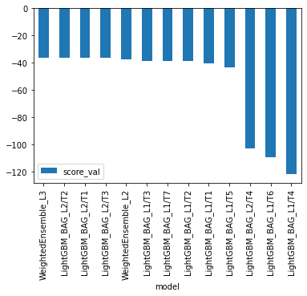

```python
# look at the model's score_val in a bar chart to analyze performance
# rename variable (to not have to redo future code)
predictor_okay = predictor_new_hpo
predictor_okay.leaderboard(silent=True).plot(kind="bar", x="model", y="score_val")
```

```python
predictor_okay.fit_summary()
```

```
*** Summary of fit() ***
Estimated performance of each model:
                  model   score_val  pred_time_val    fit_time  pred_time_val_marginal  fit_time_marginal  stack_level  can_infer  fit_order
0   WeightedEnsemble_L3  -36.209501       0.002986  222.390311                0.001368           0.515141            3       True         13
1    LightGBM_BAG_L2/T2  -36.345406       0.001485  197.520984                0.000092          29.242200            2       True         10
2    LightGBM_BAG_L2/T1  -36.541153       0.001502  191.569924                0.000109          23.291139            2       True          9
3    LightGBM_BAG_L2/T3  -36.562718       0.001526  192.632970                0.000133          24.354186            2       True         11
4   WeightedEnsemble_L2  -37.636939       0.001673   72.890188                0.001310           0.576862            2       True          8
5    LightGBM_BAG_L1/T3  -38.560441       0.000129   24.017761                0.000129          24.017761            1       True          3
6    LightGBM_BAG_L1/T7  -38.619838       0.000132   23.195906                0.000132          23.195906            1       True          7
7    LightGBM_BAG_L1/T2  -38.860855       0.000103   25.099659                0.000103          25.099659            1       True          2
8    LightGBM_BAG_L1/T1  -40.255449       0.000138   23.290410                0.000138          23.290410            1       True          1
9    LightGBM_BAG_L1/T5  -43.211088       0.000144   23.288851                0.000144          23.288851            1       True          5
10   LightGBM_BAG_L2/T4 -102.754323       0.001522  193.642765                0.000129          25.363981            2       True         12
11   LightGBM_BAG_L1/T6 -109.565161       0.000132   24.348848                0.000132          24.348848            1       True          6
12   LightGBM_BAG_L1/T4 -121.997833       0.000617   25.037350                0.000617          25.037350            1       True          4
Number of models trained: 13
Types of models trained:
{'WeightedEnsembleModel', 'StackerEnsembleModel_LGB'}
Bagging used: True  (with 8 folds)
Multi-layer stack-ensembling used: True  (with 3 levels)
Feature Metadata (Processed):
(raw dtype, special dtypes):
('category', [])             : 2 | ['season', 'weather']
('float', [])                : 3 | ['temp', 'atemp', 'windspeed']
('int', [])                  : 4 | ['humidity', 'month', 'day', 'hour']
('int', ['bool'])            : 3 | ['holiday', 'workingday', 'year']
('int', ['datetime_as_int']) : 5 | ['datetime', 'datetime.year', 'datetime.month', 'datetime.day', 'datetime.dayofweek']
Plot summary of models saved to file: AutogluonModels/ag-20230531_055336/SummaryOfModels.html
*** End of fit() summary ***
```

[output not shown]

[output cut: 109 more lines]

```

     fit_order
 0          13
 1          10
 2           9
 3          11
 4           8
 5           3
 6           7
 7           2
 8           1
 9           5
 10         12
 11          6
 12          4  }
```

```python
predictions_okay = predictor_okay.predict(test)
predictions_okay.head()
```

```
0    10.468281
1     6.531378
2     5.971393
3     5.970199
4     5.970199
Name: count, dtype: float32
```

```python
# Describe the `predictions` series to see if there are any negative values
predictions_okay.describe()
```

```
count    6493.000000
mean      192.005692
std       174.131973
min         5.195551
25%        45.409126
50%       150.120865
75%       288.417206
max       869.874573
Name: count, dtype: float64
```

```python
# count negatives
predictions_okay.lt(0).value_counts()
```

```
False    6493
Name: count, dtype: int64
```

```python
# Remember to set all negative values to zero
predictions_okay.iloc[predictions_okay<0] = 0
```

```python
# Same submitting predictions
submission_okay = pd.read_csv("./sampleSubmission.csv", parse_dates=["datetime"])
submission_okay["count"] = predictions_okay
submission_okay.to_csv("submission_okay.csv", index=False)
```

```python
!kaggle competitions submit -c bike-sharing-demand -f submission_okay.csv -m "okay"
```

```
Successfully submitted to Bike Sharing Demand
```

```python
!kaggle competitions submissions -c bike-sharing-demand | tail -n +1 | head -n 6
```

```
fileName                           date                 description                             status    publicScore  privateScore
---------------------------------  -------------------  --------------------------------------  --------  -----------  ------------
submission_okay.csv                2023-05-31 06:05:42  okay                                    complete  0.48355      0.48355
submission_regression.csv          2023-05-31 05:49:27  regression                              complete  0.67088      0.67088
final_submission_new_features.csv  2023-05-31 05:34:02  final new features                      complete  0.67897      0.67897
final_submission_new_features.csv  2023-05-31 05:24:20  final new features                      complete  0.67897      0.67897
```

```python
#### Okay (but best score of all) score is 0.4835
```

```python
### Past Trial Runs of Hyperparams (for testing, but not used in final plots)
```

```python
import autogluon.core as ag
predictor_new_hpo = TabularPredictor(label="count", eval_metric="root_mean_squared_error",learner_kwargs={"ignored_columns":["casual","registered"]}).fit(train_data=train, time_limit=600, num_bag_folds=5, num_bag_sets=1, num_stack_levels=1, presets="best_quality")
```

[output not shown]

[output cut: 100 more lines]

[output not shown]

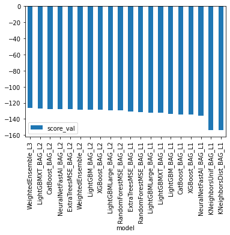

```python
# look at the model's score_val in a bar chart to analyze performance
predictor_new_hpo.leaderboard(silent=True).plot(kind="bar", x="model", y="score_val")
```

```python
predictor_new_hpo.fit_summary()
```

```
*** Summary of fit() ***
Estimated performance of each model:
                     model   score_val  pred_time_val    fit_time  pred_time_val_marginal  fit_time_marginal  stack_level  can_infer  fit_order
0      WeightedEnsemble_L3 -126.337405       8.951429  422.232820                0.001123           0.693164            3       True         20
1        LightGBMXT_BAG_L2 -127.131624       7.821158  301.616715                0.151566          13.899490            2       True         12
2          CatBoost_BAG_L2 -127.474074       7.767992  323.517629                0.098399          35.800403            2       True         15
3   NeuralNetFastAI_BAG_L2 -127.545310       8.087221  362.925563                0.417628          75.208338            2       True         17
4     ExtraTreesMSE_BAG_L2 -127.733235       8.282714  296.631427                0.613121           8.914201            2       True         16
5      WeightedEnsemble_L2 -128.188993       5.425586  117.097242                0.003260           0.775337            2       True         11
6          LightGBM_BAG_L2 -128.586515       7.754079  301.324016                0.084486          13.606790            2       True         13
7           XGBoost_BAG_L2 -128.638850       7.831747  308.858166                0.162154          21.140941            2       True         18
8     LightGBMLarge_BAG_L2 -129.142448       7.840037  309.001930                0.170444          21.284705            2       True         19
9   RandomForestMSE_BAG_L2 -129.186442       8.313236  321.850767                0.643644          34.133542            2       True         14
10    ExtraTreesMSE_BAG_L1 -130.909419       0.517965    4.348604                0.517965           4.348604            1       True          7
11  RandomForestMSE_BAG_L1 -131.489725       0.521195    7.946730                0.521195           7.946730            1       True          5
12    LightGBMLarge_BAG_L1 -132.230402       0.537096   17.335285                0.537096          17.335285            1       True         10
13       LightGBMXT_BAG_L1 -132.418571       4.019174   27.906990                4.019174          27.906990            1       True          3
14         LightGBM_BAG_L1 -133.483413       0.944765   15.769057                0.944765          15.769057            1       True          4
15         CatBoost_BAG_L1 -134.403426       0.139203  116.657665                0.139203         116.657665            1       True          6
16          XGBoost_BAG_L1 -134.625006       0.316136   21.544254                0.316136          21.544254            1       True          9
17  NeuralNetFastAI_BAG_L1 -135.738365       0.363991   76.119580                0.363991          76.119580            1       True          8
18   KNeighborsUnif_BAG_L1 -154.031089       0.103843    0.026150                0.103843           0.026150            1       True          1
19   KNeighborsDist_BAG_L1 -154.183366       0.206224    0.062911                0.206224           0.062911            1       True          2
Number of models trained: 20
Types of models trained:
{'StackerEnsembleModel_KNN', 'StackerEnsembleModel_XGBoost', 'StackerEnsembleModel_LGB', 'WeightedEnsembleModel', 'StackerEnsembleModel_NNFastAiTabular', 'StackerEnsembleModel_CatBoost', 'StackerEnsembleModel_XT', 'StackerEnsembleModel_RF'}
Bagging used: True  (with 5 folds)
Multi-layer stack-ensembling used: True  (with 3 levels)
Feature Metadata (Processed):
(raw dtype, special dtypes):
('category', [])  : 2 | ['season', 'weather']
('float', [])     : 3 | ['temp', 'atemp', 'windspeed']
('int', [])       : 3 | ['humidity', 'month', 'day']
('int', ['bool']) : 3 | ['holiday', 'workingday', 'year']
Plot summary of models saved to file: AutogluonModels/ag-20230530_194746/SummaryOfModels.html
*** End of fit() summary ***
```

[output not shown]

[output cut: 199 more lines]

```
 5          11
 6          13
 7          18
 8          19
 9          14
 10          7
 11          5
 12         10
 13          3
 14          4
 15          6
 16          9
 17          8
 18          1
 19          2  }
```

```python
# Remember to set all negative values to zero
predictions_new_hpo = predictor_new_hpo.predict(test)
predictions_new_hpo.iloc[predictions_new_hpo.lt(0)] = 0
```

```python
# Same submitting predictions
submission_new_hpo = pd.read_csv("./sampleSubmission.csv", parse_dates=["datetime"])
submission_new_hpo["count"] = predictions_new_hpo
submission_new_hpo.to_csv("submission_new_hpo.csv", index=False)
```

```python
!kaggle competitions submit -c bike-sharing-demand -f submission_new_hpo.csv -m "new features with hyperparameters"
```

```
Successfully submitted to Bike Sharing Demand
```

```python
!kaggle competitions submissions -c bike-sharing-demand | tail -n +1 | head -n 6
```

```
fileName                     date                 description                        status    publicScore  privateScore
---------------------------  -------------------  ---------------------------------  --------  -----------  ------------
submission_new_hpo.csv       2023-05-30 20:03:50  new features with hyperparameters  complete  1.33144      1.33144
submission_new_features.csv  2023-05-30 18:54:32  new features                       complete  1.33755      1.33755
submission.csv               2023-05-30 18:27:43  first raw submission               complete  1.79188      1.79188
```

#### New Score of 1.33144

```python
#### Hyper Parameter Optimization BEST NEW
```

```python
import autogluon.core as ag
# get rid of time limit
#
new_predictor_hpo_best = TabularPredictor(label="count", eval_metric="root_mean_squared_error",learner_kwargs={"ignored_columns":["casual","registered"]}).fit(train_data=train, num_bag_folds=8, num_bag_sets=1, num_stack_levels=1, hyperparameters = {'NN_TORCH': {'num_epochs': 10}}, presets="best_quality")
```

[output not shown]

[output cut: 18 more lines]

```
	-143.5812	 = Validation score   (-root_mean_squared_error)
	0.0s	 = Training   runtime
	0.0s	 = Validation runtime
Fitting 1 L2 models ...
Fitting model: NeuralNetTorch_BAG_L2 ...
	Fitting 8 child models (S1F1 - S1F8) | Fitting with ParallelLocalFoldFittingStrategy
	-144.532	 = Validation score   (-root_mean_squared_error)
	52.12s	 = Training   runtime
	0.18s	 = Validation runtime
Fitting model: WeightedEnsemble_L3 ...
	-144.532	 = Validation score   (-root_mean_squared_error)
	0.01s	 = Training   runtime
	0.0s	 = Validation runtime
AutoGluon training complete, total runtime = 114.24s ... Best model: "WeightedEnsemble_L2"
TabularPredictor saved. To load, use: predictor = TabularPredictor.load("AutogluonModels/ag-20230530_225347/")
```

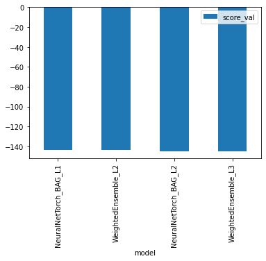

```python
# look at the model's score_val in a bar chart to analyze performance
new_predictor_hpo_best.leaderboard(silent=True).plot(kind="bar", x="model", y="score_val")
```

```python
new_predictor_hpo_best.fit_summary()
```

```
*** Summary of fit() ***
Estimated performance of each model:
                   model   score_val  pred_time_val    fit_time  pred_time_val_marginal  fit_time_marginal  stack_level  can_infer  fit_order
0  NeuralNetTorch_BAG_L1 -143.581228       0.166683   53.200869                0.166683          53.200869            1       True          1
1    WeightedEnsemble_L2 -143.581228       0.167687   53.205270                0.001004           0.004401            2       True          2
2  NeuralNetTorch_BAG_L2 -144.531964       0.342744  105.319801                0.176061          52.118932            2       True          3
3    WeightedEnsemble_L3 -144.531964       0.344080  105.326067                0.001337           0.006266            3       True          4
Number of models trained: 4
Types of models trained:
{'WeightedEnsembleModel', 'StackerEnsembleModel_TabularNeuralNetTorch'}
Bagging used: True  (with 8 folds)
Multi-layer stack-ensembling used: True  (with 3 levels)
Feature Metadata (Processed):
(raw dtype, special dtypes):
('category', [])  : 2 | ['season', 'weather']
('float', [])     : 3 | ['temp', 'atemp', 'windspeed']
('int', [])       : 3 | ['humidity', 'month', 'day']
('int', ['bool']) : 3 | ['holiday', 'workingday', 'year']
Plot summary of models saved to file: AutogluonModels/ag-20230530_225347/SummaryOfModels.html
*** End of fit() summary ***
```

[output not shown]

```python
# Remember to set all negative values to zero
new_predictions_hpo_best = new_predictor_hpo_best.predict(test)
new_predictions_hpo_best.iloc[new_predictions_hpo_best.lt(0)] = 0
```

```python
# Same submitting predictions
new_submission_hpo_best = pd.read_csv('./sampleSubmission.csv', parse_dates=["datetime"])
new_submission_hpo_best["count"] = new_predictions_hpo_best
new_submission_hpo_best.to_csv("new_submission_hpo_best.csv", index=False)
```

```python
!kaggle competitions submit -c bike-sharing-demand -f new_submission_hpo_best.csv -m "best new features with hyperparameters"
```

```
Successfully submitted to Bike Sharing Demand
```

```python
!kaggle competitions submissions -c bike-sharing-demand | tail -n +1 | head -n 6
```

```
fileName                           date                 description                             status    publicScore  privateScore
---------------------------------  -------------------  --------------------------------------  --------  -----------  ------------
new_submission_hpo_best.csv        2023-05-30 22:56:40  best new features with hyperparameters  complete  1.19182      1.19182
submission_new_hpo_best_check.csv  2023-05-30 21:28:58  best new features with hyperparameters  complete  1.18880      1.18880
submission_new_hpo_best_new.csv    2023-05-30 21:23:04  best new features with hyperparameters  complete  1.19182      1.19182
submission_new_hpo_best.csv        2023-05-30 20:18:54  best new features with hyperparameters  complete  1.18880      1.18880
```

```python
#### New score of 1.19182
```

```python
#### Hyper Parameter Optimization BEST
```

```python
import autogluon.core as ag
# get rid of time limit
#
predictor_new_hpo_best = TabularPredictor(label="count", eval_metric="root_mean_squared_error",learner_kwargs={"ignored_columns":["casual","registered"]}).fit(train_data=train, num_bag_folds=5, num_bag_sets=1, num_stack_levels=1, hyperparameters = {'NN_TORCH': {'num_epochs': 2}}, presets="best_quality")
```

[output not shown]

[output cut: 18 more lines]

```
	-151.1691	 = Validation score   (-root_mean_squared_error)
	0.0s	 = Training   runtime
	0.0s	 = Validation runtime
Fitting 1 L2 models ...
Fitting model: NeuralNetTorch_BAG_L2 ...
	Fitting 5 child models (S1F1 - S1F5) | Fitting with ParallelLocalFoldFittingStrategy
	-150.6605	 = Validation score   (-root_mean_squared_error)
	14.09s	 = Training   runtime
	0.18s	 = Validation runtime
Fitting model: WeightedEnsemble_L3 ...
	-150.6605	 = Validation score   (-root_mean_squared_error)
	0.0s	 = Training   runtime
	0.0s	 = Validation runtime
AutoGluon training complete, total runtime = 37.45s ... Best model: "WeightedEnsemble_L3"
TabularPredictor saved. To load, use: predictor = TabularPredictor.load("AutogluonModels/ag-20230530_212656/")
```

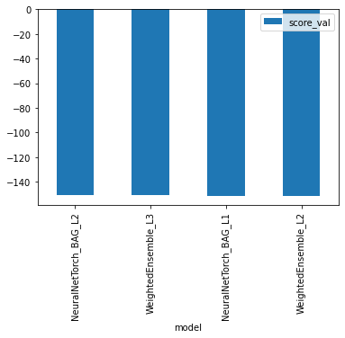

```python
# look at the model's score_val in a bar chart to analyze performance
predictor_new_hpo_best.leaderboard(silent=True).plot(kind="bar", x="model", y="score_val")
```

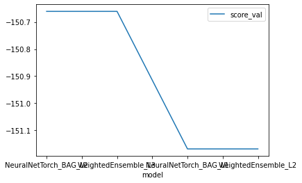

```python
# look at the model's score_val in a line chart to analyze performance
predictor_new_hpo_best.leaderboard(silent=True).plot(kind="line", x="model", y="score_val")
```

```python
predictor_new_hpo_best.fit_summary()
```

```
*** Summary of fit() ***
Estimated performance of each model:
                   model   score_val  pred_time_val   fit_time  pred_time_val_marginal  fit_time_marginal  stack_level  can_infer  fit_order
0  NeuralNetTorch_BAG_L2 -150.660535       0.430138  29.085063                0.184607          14.089447            2       True          3
1    WeightedEnsemble_L3 -150.660535       0.430911  29.089223                0.000773           0.004160            3       True          4
2  NeuralNetTorch_BAG_L1 -151.169069       0.245531  14.995615                0.245531          14.995615            1       True          1
3    WeightedEnsemble_L2 -151.169069       0.246360  15.000245                0.000829           0.004630            2       True          2
Number of models trained: 4
Types of models trained:
{'WeightedEnsembleModel', 'StackerEnsembleModel_TabularNeuralNetTorch'}
Bagging used: True  (with 5 folds)
Multi-layer stack-ensembling used: True  (with 3 levels)
Feature Metadata (Processed):
(raw dtype, special dtypes):
('category', [])  : 2 | ['season', 'weather']
('float', [])     : 3 | ['temp', 'atemp', 'windspeed']
('int', [])       : 3 | ['humidity', 'month', 'day']
('int', ['bool']) : 3 | ['holiday', 'workingday', 'year']
Plot summary of models saved to file: AutogluonModels/ag-20230530_212656/SummaryOfModels.html
*** End of fit() summary ***
```

[output not shown]

```python
# Remember to set all negative values to zero
predictions_new_hpo_best = predictor_new_hpo_best.predict(test)
predictions_new_hpo_best.iloc[predictions_new_hpo_best.lt(0)] = 0
```

```python
# Same submitting predictions
submission_new_hpo_best = pd.read_csv('./sampleSubmission.csv', parse_dates=["datetime"])
submission_new_hpo_best["count"] = predictions_new_hpo_best
submission_new_hpo_best.to_csv("submission_new_hpo_best_check.csv", index=False)
```

```python
!kaggle competitions submit -c bike-sharing-demand -f submission_new_hpo_best_check.csv -m "best new features with hyperparameters"
```

```
Successfully submitted to Bike Sharing Demand
```

```python
!kaggle competitions submissions -c bike-sharing-demand | tail -n +1 | head -n 6
```

```
fileName                           date                 description                             status    publicScore  privateScore
---------------------------------  -------------------  --------------------------------------  --------  -----------  ------------
submission_new_hpo_best_check.csv  2023-05-30 21:28:58  best new features with hyperparameters  complete  1.18880      1.18880
submission_new_hpo_best_new.csv    2023-05-30 21:23:04  best new features with hyperparameters  complete  1.19182      1.19182
submission_new_hpo_best.csv        2023-05-30 20:18:54  best new features with hyperparameters  complete  1.18880      1.18880
submission_new_hpo.csv             2023-05-30 20:03:50  new features with hyperparameters       complete  1.33144      1.33144
```

```python
#### Best Score of 1.18880
```